# Vector Analysis

Evan Batzer

November 8, 2018

Compiled on Thu Dec 13 15:26:28 2018

# Fertilization Vector Analysis

## Results of statistical consultation

Per discussions with Neil Willits, the two different ways that I could try to analyze the nutrient enrichment tradeoff include:

- Conducting a PCA on each site and trying to evaluate nutrient enrichment change as a linear model. In this case, we have Y = PC1 score (or some other principal component axis), and
  $$Y = \mu + \beta_i t + f_i(t)$$
  , where $\beta_i$ is the effect of nutrient enrichment over time and $f_i$ is a nonlinear term that reflects the fact that the relationship between time and response isn’t apt to be linear.
  - To evaluate the tradeoff between nutrient addition treatments (or if this surface exists at all!), we can compare the values of the beta coefficient. For example, $\beta_N$ - $\beta_P$ is equal to the tradeoff on this axis. The more negative value this is, the greater of a tradeoff we see.
  - However, I’m not crazy about this approach, in large part because of the difficulty in picking the appropriate principal components. How can we standardize this process over multiple sites? Without running the analysis over all of the total variation between sites, this is not clear to me.
- Another way to do this analysis is quite similar to what we had talked about in our last meeting. But rather than actually calculating the multivariate angle by the formula:
  $$\cos (\theta) = \frac{(\vec{V_N} \cdot \vec{V_P})}{\left\lVert\vec{V_N}
  \right\rVert \left\lVert\vec{V_P}\right\rVert}$$
  we can instead just focus on the dot product itself, or the ratio relative to the magnitude of each vector.
  - Neil suggested that the computation that derives the angle $\theta$ can be a little unstable. Focusing on the dot product (if we divide by the magnitude or convert to unit length) can give us a value between -1 and 1, which indicates travel in either the same or opposite directions.
  - I like this approach more, because it doesn’t rely on a dimensionality reduction, or a summary statistic like grass/forb/legume cover.

## PermANOVA analysis

**Steps:**

1. Run permANOVA for each site, specifying:
   - Permutations only within blocks
   - Model formula of Y ~ Year + Average Treatment Effect
     - Can also specify a linear term of treatment, or variation across years
2. Summarize this data by tabulating each time the permANOVA produces significant results. Which sites show community change by N, P, and K? Should we just subset to these sites with significant results?
3. Extract vectors of community change in response to N, P, and K.
- Also attach whether this estimated effect was significant
- Standardize to unit length?
4. Calculate the dot product for each pairwise set of vectors. Store this value (should likely be roughly bounded between -1 and 1)
5. To establish which sorts of sites seem to experience this tradeoff, we can perform some sort of hierarchical clustering algorithm. Neil suggested using conditional inference trees with some sort of univariate control, as opposed to the standard Bonferroni method.

## Fitting PerMANOVA to these sites

To extract estimated species responses to treatment, I’m following a similar protocol as we did in the NutNet meeting this summer. After fitting the PerMANOVA, I’ve extracted all of the estimated species responses to the three nutrients we’re interested in - N, P, and K.

The response coefficient is the estimated mean response of that species over all years of sampling (at least 5). I’ve also standardized total observations per column - it may make sense to not just look at absolute cover, but rather, the relative % cover of species in each observed plot.

## Calculate dot-product of pairwise correlations

Given these estimated parameters, we can calculate the correlation between species responses to different pairs of nutrient treatments through the dot-product of the fitted vectors between treatments within a site.

After calculating this dot-product, the distributions of each set correlation scores can be seen in histograms below:

- Values close to zero indicate that species responses to two treatments within a site are not correlated with one another.
- Values close to one or negative one indicate that species responses to two treatments within a site are highly positively or negatively correlated.

In these histograms, I’ve only showed sites where both nutrient additions in each pair had significant effects in the permutational ANOVA.

I think this output highlights two key patterns:

- Species responses to N & P fertilization and N & K fertilization are not particularly correlated
- Species responses to P & K fertilization tend to be correlated with one another.

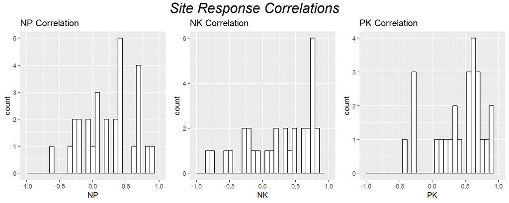

To get a sense of what sites seem to be showing the strongest or weakest tradeoffs, I’ve ranked these scores and plotted them with site labels. Each bar is filled when the results of the permutational ANOVA indicate that both elements of the fertilization tradeoff were significant. This figure may not make a whole lot of sense without prior knowledge of the site distribution, but is useful in thinking about what sites might show the biggest tradeoff.

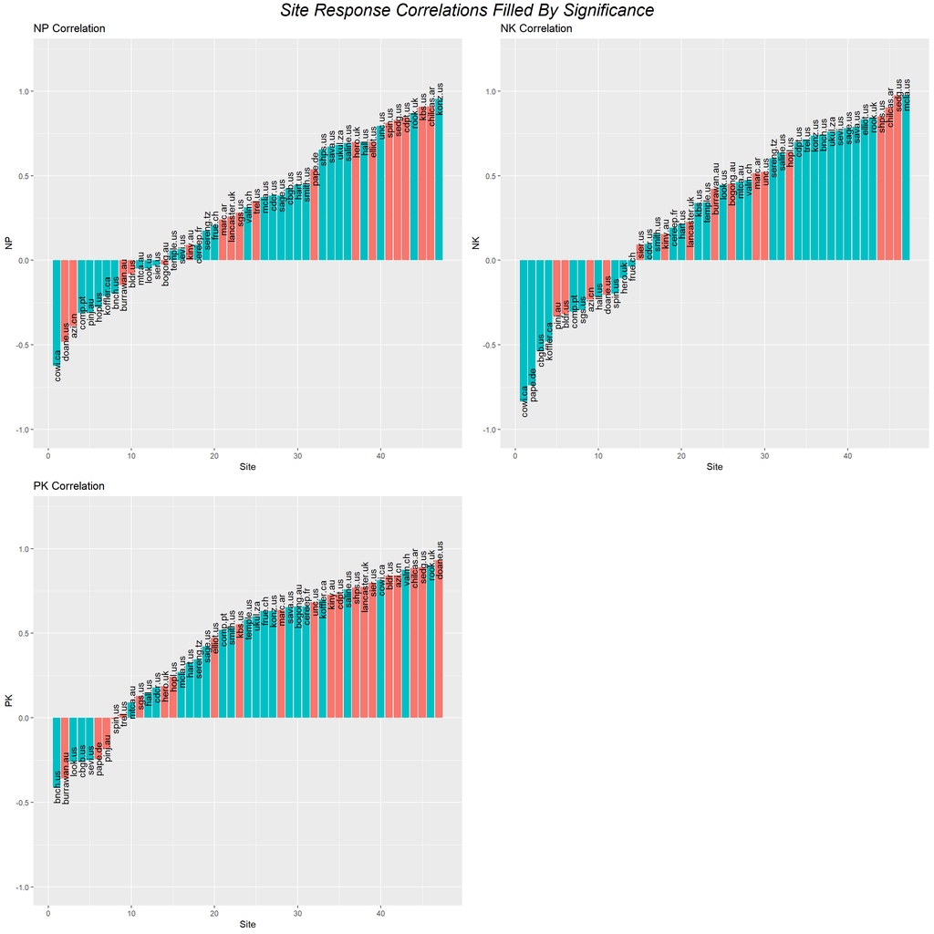

I’ve also highlighted a couple of these below, plotting an RDA of the same model used to generate the species responses to the different nutrients. This is mostly a proof of concept. Are the values we extract from this metric pretty similar to our results if we just examine the angles between vectors in an ordination?

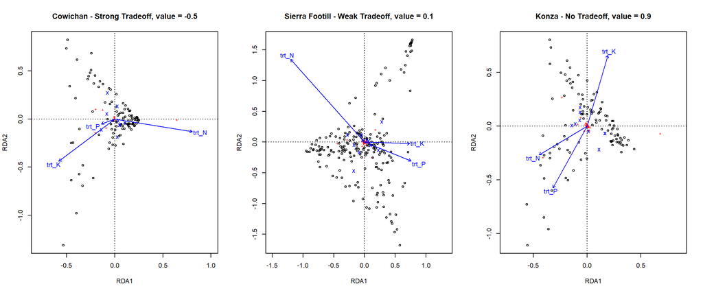

# What variables are correlated with different tradeoff axes?

## Simple univariate exploration

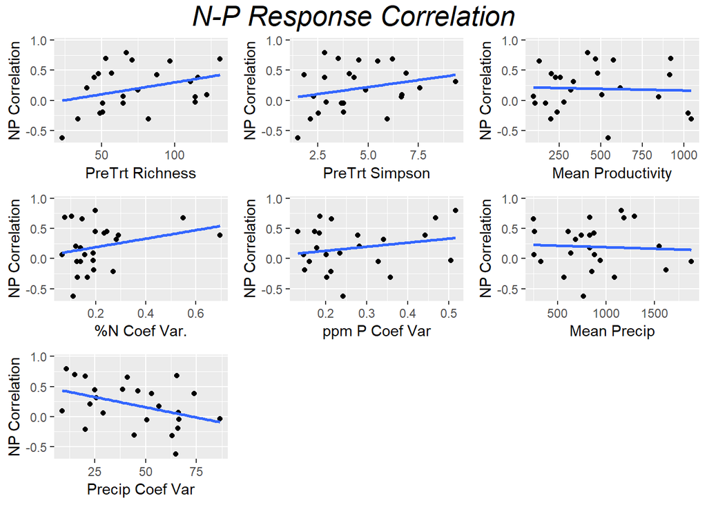

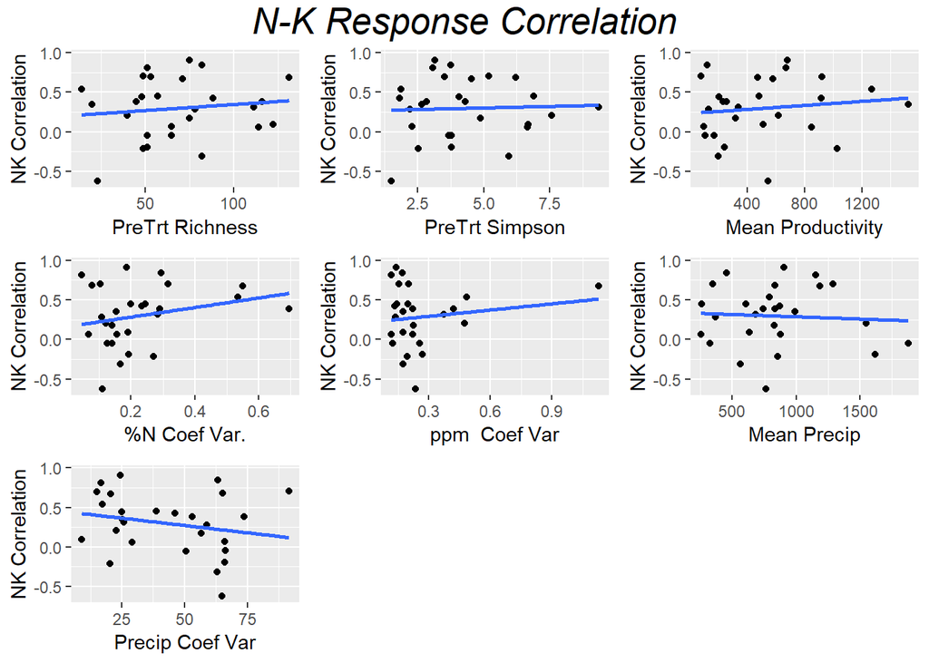

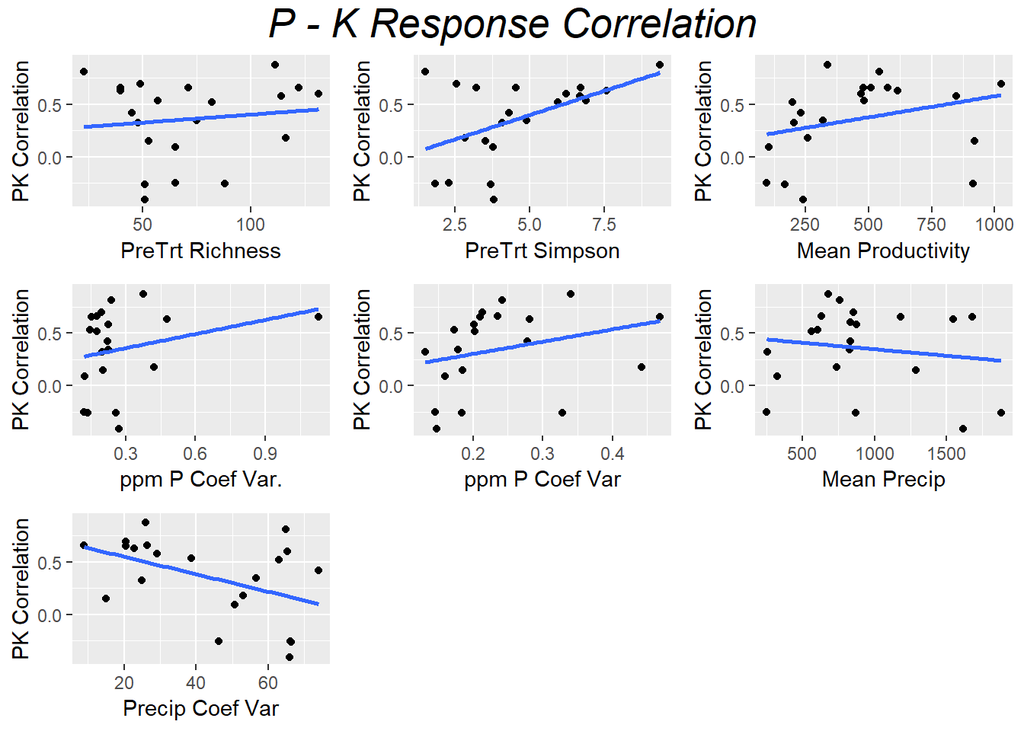